# Analyse en Composantes Principales

Jeu de données data_bwd_fwd_2019

Ce jeu de données contient 24 individus et 34 variables, 17 variables quantitatives sont illustratives.

### 1. Observation d’individus extrêmes

L’analyse des graphes détecte des individus singuliers qui influencent très fortement les résultats observés. On soulignera dans un premier temps le caractère extrême de ces individus avant de les retirer pour procéder à la suite de l’analyse. En observant le graphe, on peut noter que 4 individus sont très particuliers et contribuent énormément à la construction du plan. Le cumul de leur contribution à la contruction du plan atteint **59.5%**.

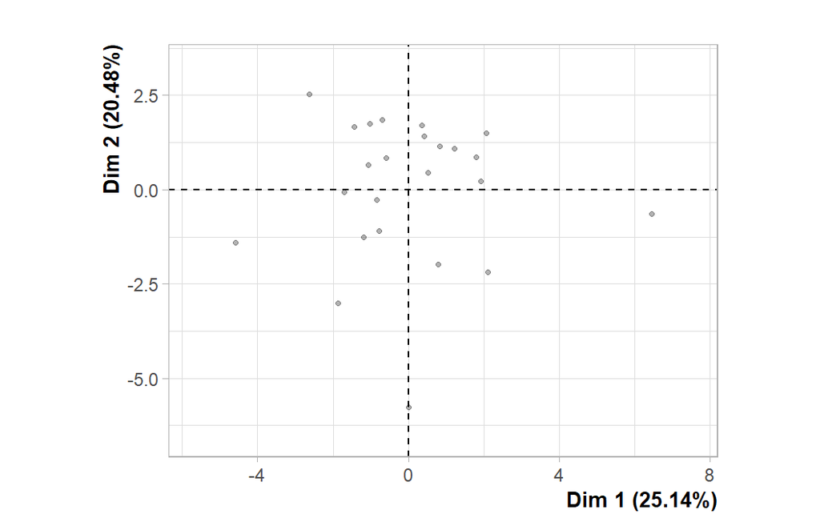

**Figure 1.1 - Graphe des individus (ACP) avant correction.** *Mise en évidence de 4 individus singuliers.*

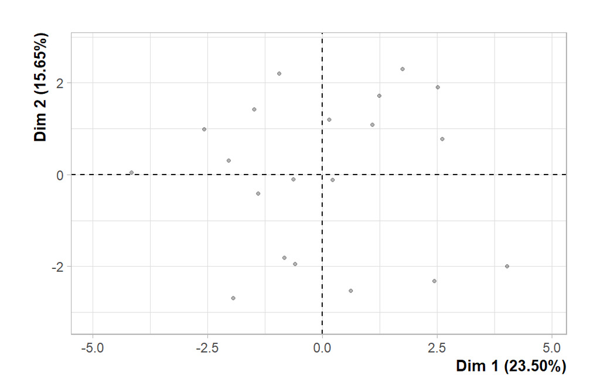

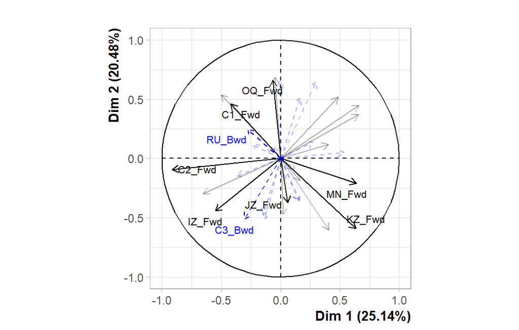

**Figure 1.3 - Graphe des variables (ACP) avant correction** *Les variables libellées sont celles les mieux représentées sur le plan.*

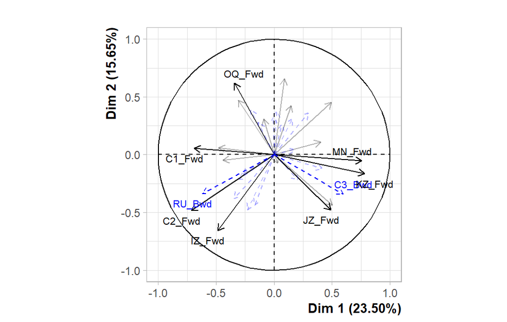

**Figure 1.3 - Graphe des variables (ACP) après correction**

**L’individu 13** :

- prend de très fortes valeurs pour le(s) variable(s) : *LZ_Fwd*, *GZ_Fwd* et *KZ_Fwd* (de la plus extrême à la moins extrême).
- prend de très faibles valeurs pour les variables : *C2_Fwd* et *C1_Fwd* (de la plus extrême à la moins extrême).

**L’individu 19** :

- prend de très fortes valeurs pour le(s) variable(s) : *DE_Fwd*.
- prend de très faibles valeurs pour les variables : *HZ_Fwd*.

### 2. Distribution de l’inertie

L’inertie des axes factoriels indique d’une part si les variables sont structurées et suggère d’autre part le nombre judicieux de composantes principales à étudier.

Les 2 premiers axes de l’ analyse expriment **39.15%** de l’inertie totale du jeu de données ; cela signifie que 39.15% de la variabilité totale du nuage des individus (ou des variables) est représentée dans ce plan. C’est un pourcentage relativement moyen, et le premier plan représente donc seulement une part de la variabilité contenue dans l’ensemble du jeu de données actif. Cette valeur est supérieure à la valeur référence de **36.73%**, la variabilité expliquée par ce plan est donc significative (cette intertie de référence est le quantile 0.95-quantile de la distribution des pourcentages d’inertie obtenue en simulant 5821 jeux de données aléatoires de dimensions comparables sur la base d’une distribution normale).

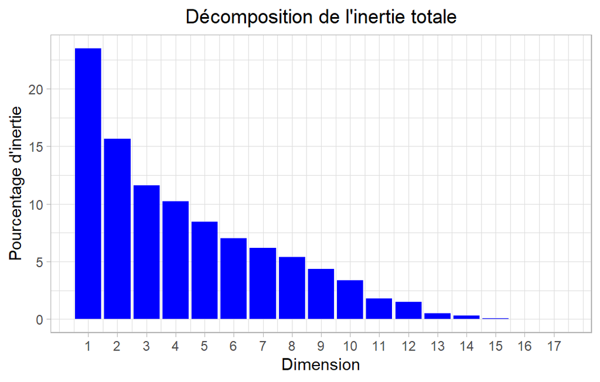

**Figure 2 - Décomposition de l’inertie totale**

Une estimation du nombre pertinent d’axes à interpréter suggère de restreindre l’analyse à la description des 2 premiers axes. Ces composantes révèlent un taux d’inertie supérieur à celle du quantile 0.95-quantile de distributions aléatoires (39.15% contre 36.73%). Cette observation suggère que seuls ces axes sont porteurs d’une véritable information. En conséquence, la description de l’analyse sera restreinte à ces seuls axes.

### 3. Description du plan 1:2

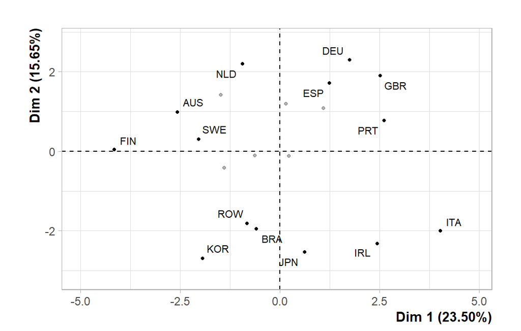

**Figure 3.1 - Graphe des individus (ACP)** *Les individus libellés sont ceux ayant la plus grande contribution à la construction du plan.*

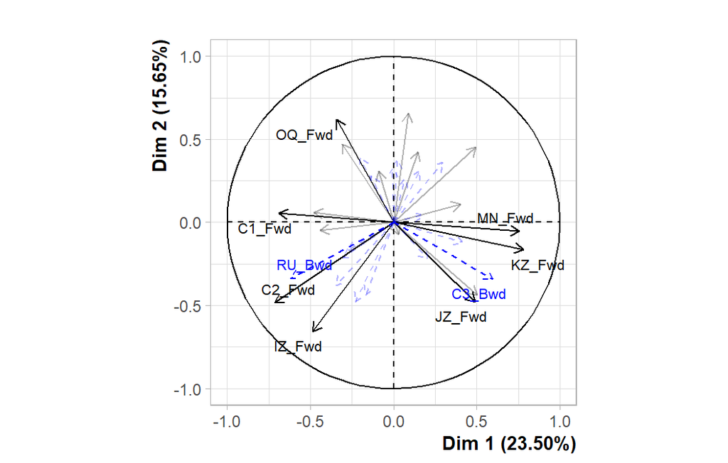

**Figure 3.2 - Graphe des variables (ACP)** *Les variables en noir sont les variables actives, celles en bleu sont les variables quantitatives supplémentaires (illustratives).* *Les variables libellées sont celles les mieux représentées sur le plan.*

La **dimension 1** oppose des individus tels que *ITA*, *PRT*, *GBR*, *DEU*, *IRL* et *ESP* (à droite du graphe, caractérisés par une coordonnée fortement positive sur l’axe) à des individus comme *FIN*, *AUS*, *SWE* et *NLD* (à gauche du graphe, caractérisés par une coordonnée fortement négative sur l’axe).

Le groupe auquel les individus *PRT*, *GBR*, *DEU* et *ESP* appartiennent (caractérisés par une coordonnée positive sur l’axe) partage :

- de fortes valeurs pour les variables *C3_Fwd*, *C4_Bwd* et *C2_Bwd* (de la plus extrême à la moins extrême).
- de faibles valeurs pour les variables *IZ_Fwd*, *RU_Bwd*, *C2_Fwd* et *IZ_Bwd* (de la plus extrême à la moins extrême).

Le groupe auquel les individus *ITA* et *IRL* appartiennent (caractérisés par une coordonnée positive sur l’axe) partage :

- de fortes valeurs pour les variables *JZ_Bwd*, *GZ_Fwd*, *JZ_Fwd* et *C3_Bwd* (de la plus extrême à la moins extrême).
- de faibles valeurs pour la variable *C5_Fwd*.

Le groupe auquel les individus *FIN*, *AUS*, *SWE* et *NLD* appartiennent (caractérisés par une coordonnées négative sur l’axe) partage :

- de fortes valeurs pour les variables *OQ_Fwd* et *LZ_Bwd* (de la plus extrême à la moins extrême).
- de faibles valeurs pour les variables *KZ_Fwd*, *JZ_Fwd*, *MN_Fwd*, *C3_Bwd* et *GZ_Fwd* (de la plus extrême à la moins extrême).

Le groupe auquel les individus *FIN*, *AUS*, *SWE* et *NLD* appartiennent (caractérisés par une coordonnée positive sur l’axe) partage :

- de fortes valeurs pour les variables *OQ_Fwd* et *LZ_Bwd* (de la plus extrême à la moins extrême).
- de faibles valeurs pour les variables *KZ_Fwd*, *JZ_Fwd*, *MN_Fwd*, *C3_Bwd* et *GZ_Fwd* (de la plus extrême à la moins extrême).

Le groupe auquel les individus *PRT*, *GBR*, *DEU* et *ESP* appartiennent (caractérisés par une coordonnée positive sur l’axe) partage :

- de fortes valeurs pour les variables *C3_Fwd*, *C4_Bwd* et *C2_Bwd* (de la plus extrême à la moins extrême).
- de faibles valeurs pour les variables *IZ_Fwd*, *RU_Bwd*, *C2_Fwd* et *IZ_Bwd* (de la plus extrême à la moins extrême).

Le groupe auquel les individus *KOR*, *JPN*, *BRA* et *ROW* appartiennent (caractérisés par une coordonnées négative sur l’axe) partage :

- de fortes valeurs pour les variables *IZ_Fwd*, *HZ_Bwd* et *C2_Fwd* (de la plus extrême à la moins extrême).
- de faibles valeurs pour la variable *LZ_Bwd*.

Le groupe auquel les individus *ITA* et *IRL* appartiennent (caractérisés par une coordonnées négative sur l’axe) partage :

- de fortes valeurs pour les variables *JZ_Bwd*, *GZ_Fwd*, *JZ_Fwd* et *C3_Bwd* (de la plus extrême à la moins extrême).
- de faibles valeurs pour la variable *C5_Fwd*.

## Annexes

```r
dimdesc(res, axes = 1:2)
```

```
$Dim.1

Link between the variable and the continuous variables (R-square)
=================================================================================
       correlation      p.value
KZ_Fwd   0.7825549 4.543722e-05
MN_Fwd   0.7576072 1.093584e-04
C3_Bwd   0.5992690 5.231991e-03
GZ_Fwd   0.5025938 2.391456e-02
C3_Fwd   0.4963083 2.602793e-02
JZ_Fwd   0.4910634 2.790187e-02
AZ_Fwd  -0.4806217 3.194769e-02
IZ_Fwd  -0.4885878 2.882248e-02
RU_Bwd  -0.6188875 3.621968e-03
C1_Fwd  -0.6906736 7.479857e-04
C2_Fwd  -0.7160450 3.841933e-04

$Dim.2

Link between the variable and the continuous variables (R-square)
=================================================================================
       correlation     p.value
FZ_Fwd   0.6570051 0.001648089
OQ_Fwd   0.6178283 0.003696850
C5_Fwd   0.4719675 0.035636995
C3_Fwd   0.4519139 0.045459756
JZ_Fwd  -0.4778079 0.033112830
FZ_Bwd  -0.4780737 0.033001343
C2_Fwd  -0.4847686 0.030289334
IZ_Fwd  -0.6566284 0.001661826
```

**Figure 4 - Liste des variables caractéristiques des dimensions de l’analyse.**